# Untitled

Rodrigo Vazquez

10/18/2017

```r
load(file="providerspokane.rda")
```

```r
setwd("~/Desktop/GitHubRepository/project1")
load("providerspokane.rda")
library(ggplot2)
library(dplyr)
library(tidyr)
```

```r
colnames(providerspokane)
```

```
##  [1] "National.Provider.Identifier"
##  [2] "Last.Name.Organization.Name.of.the.Provider"
##  [3] "First.Name.of.the.Provider"
##  [4] "Middle.Initial.of.the.Provider"
##  [5] "Credentials.of.the.Provider"
##  [6] "Gender.of.the.Provider"
##  [7] "Entity.Type.of.the.Provider"
##  [8] "Street.Address.1.of.the.Provider"
##  [9] "Street.Address.2.of.the.Provider"
## [10] "City.of.the.Provider"
## [11] "Zip.Code.of.the.Provider"
## [12] "State.Code.of.the.Provider"
## [13] "Country.Code.of.the.Provider"
## [14] "Provider.Type"
## [15] "Medicare.Participation.Indicator"
## [16] "Place.of.Service"
## [17] "HCPCS.Code"
## [18] "HCPCS.Description"
## [19] "HCPCS.Drug.Indicator"
## [20] "Number.of.Services"
## [21] "Number.of.Medicare.Beneficiaries"
## [22] "Number.of.Distinct.Medicare.Beneficiary.Per.Day.Services"
## [23] "Average.Medicare.Allowed.Amount"
## [24] "Average.Submitted.Charge.Amount"
## [25] "Average.Medicare.Payment.Amount"
## [26] "Average.Medicare.Standardized.Amount"
```

```r
names(providerspokane)[6]="Gender"
names(providerspokane)
```

```
##  [1] "National.Provider.Identifier"
##  [2] "Last.Name.Organization.Name.of.the.Provider"
##  [3] "First.Name.of.the.Provider"
##  [4] "Middle.Initial.of.the.Provider"
##  [5] "Credentials.of.the.Provider"
##  [6] "Gender"
##  [7] "Entity.Type.of.the.Provider"
##  [8] "Street.Address.1.of.the.Provider"
##  [9] "Street.Address.2.of.the.Provider"
## [10] "City.of.the.Provider"
## [11] "Zip.Code.of.the.Provider"
## [12] "State.Code.of.the.Provider"
## [13] "Country.Code.of.the.Provider"
## [14] "Provider.Type"
## [15] "Medicare.Participation.Indicator"
## [16] "Place.of.Service"
## [17] "HCPCS.Code"
## [18] "HCPCS.Description"
## [19] "HCPCS.Drug.Indicator"
## [20] "Number.of.Services"
## [21] "Number.of.Medicare.Beneficiaries"
## [22] "Number.of.Distinct.Medicare.Beneficiary.Per.Day.Services"
## [23] "Average.Medicare.Allowed.Amount"
## [24] "Average.Submitted.Charge.Amount"
## [25] "Average.Medicare.Payment.Amount"
## [26] "Average.Medicare.Standardized.Amount"
```

```r
names(providerspokane)[20]="numServices"
names(providerspokane)[14]="providerType"
names(providerspokane)[1]="id"
names(providerspokane)[16]="servicePlace"
```

```r
colnames(providerspokane)
```

```
##  [1] "id"
##  [2] "Last.Name.Organization.Name.of.the.Provider"
##  [3] "First.Name.of.the.Provider"
##  [4] "Middle.Initial.of.the.Provider"
##  [5] "Credentials.of.the.Provider"
##  [6] "Gender"
##  [7] "Entity.Type.of.the.Provider"
##  [8] "Street.Address.1.of.the.Provider"
##  [9] "Street.Address.2.of.the.Provider"
## [10] "City.of.the.Provider"
## [11] "Zip.Code.of.the.Provider"
## [12] "State.Code.of.the.Provider"
## [13] "Country.Code.of.the.Provider"
## [14] "providerType"
## [15] "Medicare.Participation.Indicator"
## [16] "servicePlace"
## [17] "HCPCS.Code"
## [18] "HCPCS.Description"
## [19] "HCPCS.Drug.Indicator"
## [20] "numServices"
## [21] "Number.of.Medicare.Beneficiaries"
## [22] "Number.of.Distinct.Medicare.Beneficiary.Per.Day.Services"
## [23] "Average.Medicare.Allowed.Amount"
## [24] "Average.Submitted.Charge.Amount"
## [25] "Average.Medicare.Payment.Amount"
## [26] "Average.Medicare.Standardized.Amount"
```

```r
colnames(providerspokane)
```

```
##  [1] "id"
##  [2] "Last.Name.Organization.Name.of.the.Provider"
##  [3] "First.Name.of.the.Provider"
##  [4] "Middle.Initial.of.the.Provider"
##  [5] "Credentials.of.the.Provider"
##  [6] "Gender"
##  [7] "Entity.Type.of.the.Provider"
##  [8] "Street.Address.1.of.the.Provider"
##  [9] "Street.Address.2.of.the.Provider"
## [10] "City.of.the.Provider"
## [11] "Zip.Code.of.the.Provider"
## [12] "State.Code.of.the.Provider"
## [13] "Country.Code.of.the.Provider"
## [14] "providerType"
## [15] "Medicare.Participation.Indicator"
## [16] "servicePlace"
## [17] "HCPCS.Code"
## [18] "HCPCS.Description"
## [19] "HCPCS.Drug.Indicator"
## [20] "numServices"
## [21] "Number.of.Medicare.Beneficiaries"
## [22] "Number.of.Distinct.Medicare.Beneficiary.Per.Day.Services"
## [23] "Average.Medicare.Allowed.Amount"
## [24] "Average.Submitted.Charge.Amount"
## [25] "Average.Medicare.Payment.Amount"
## [26] "Average.Medicare.Standardized.Amount"
```

## Question 1: Are there differences in the number of services, distinct beneficiary per day services, average medicare allowed, charged, and paid amount, and medicare standardized amount differ as a function of Gender, the Provider Type, and Place of Service.

## Create New Dataset for Gender

```r
Genderstudy=providerspokane %>% select(Gender, Number.of.Distinct.Medicare.Beneficiary.Per.Day.Services, Average.Medicare.Allowed.Amount, Average.Submitted.Charge.Amount, numServices, Average.Medicare.Standardized.Amount, Average.Medicare.Payment.Amount)
```

## Create New Dataset for Provider.Type

```r
ProviderType=providerspokane %>% select(providerType, Number.of.Distinct.Medicare.Beneficiary.Per.Day.Services, Average.Medicare.Allowed.Amount, Average.Submitted.Charge.Amount, numServices, Average.Medicare.Standardized.Amount, Average.Medicare.Payment.Amount)
```

## Create New Dataset for Place.of.Service

```r
PlaceService=providerspokane %>% select(servicePlace, Number.of.Distinct.Medicare.Beneficiary.Per.Day.Services, Average.Medicare.Allowed.Amount, Average.Submitted.Charge.Amount, numServices, Average.Medicare.Standardized.Amount, Average.Medicare.Payment.Amount)
```

## Medicare Varibales as a Function of Place of Service:

```r
servicePlace.mean=providerspokane%>%group_by(servicePlace)%>%summarize(numberofservices=mean(numServices),numberofdistinctmedicarebeneficiaryperdayservices=mean(Number.of.Distinct.Medicare.Beneficiary.Per.Day.Services),averagemedicareallowed=mean(Average.Medicare.Allowed.Amount),averagemedicarecharged=mean(Average.Submitted.Charge.Amount),averagemedicarepayment=mean(Average.Medicare.Payment.Amount),averagemedicarestandarizedamount=mean(Average.Medicare.Standardized.Amount))
```

```r
servicePlace.mean.filter=filter(servicePlace.mean, numberofservices<1000)
```

```r
Servicemeanfiltergather=gather(servicePlace.mean.filter, "Service", "mean", c(2, 3, 4, 5, 6, 7))
```

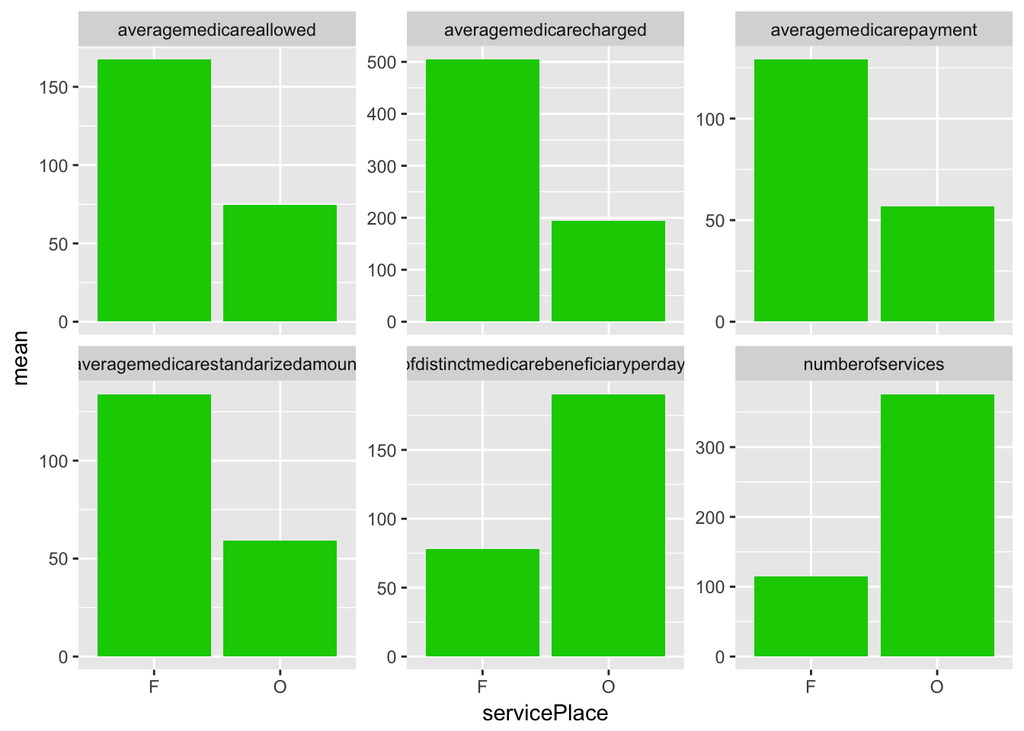

```r
ggplot(Servicemeanfiltergather,aes(servicePlace,mean))+geom_bar(stat="identity", fill=67)+ facet_wrap(~Service, scale = "free_y")
```

### Analysis of Place of Service

These graph about place of service, you can see a trend illustrating the differences between facilities and offices. You can see that facilities (represented by “F”) such as hospitals charge more but provide less services, wheres with the offices (represented by “O”) charge less for what they do and actually provide more services.

## Medicare Varaibles as a Function of Gender

```r
gender.mean=providerspokane%>%group_by(Gender)%>%summarize(numberofservices=mean(numServices),numberofdistinctmedicarebeneficiaryperdayservices=mean(Number.of.Distinct.Medicare.Beneficiary.Per.Day.Services),averagemedicareallowed=mean(Average.Medicare.Allowed.Amount),averagemedicarecharged=mean(Average.Submitted.Charge.Amount),averagemedicarepayment=mean(Average.Medicare.Payment.Amount),averagemedicarestandarizedamount=mean(Average.Medicare.Standardized.Amount))
```

```r
gender.mean.filter=filter(gender.mean, numberofservices<1000)
```

```r
gendermeanfiltergather=gather(gender.mean.filter, "Service", "mean", c(2, 3, 4, 5, 6, 7))
```

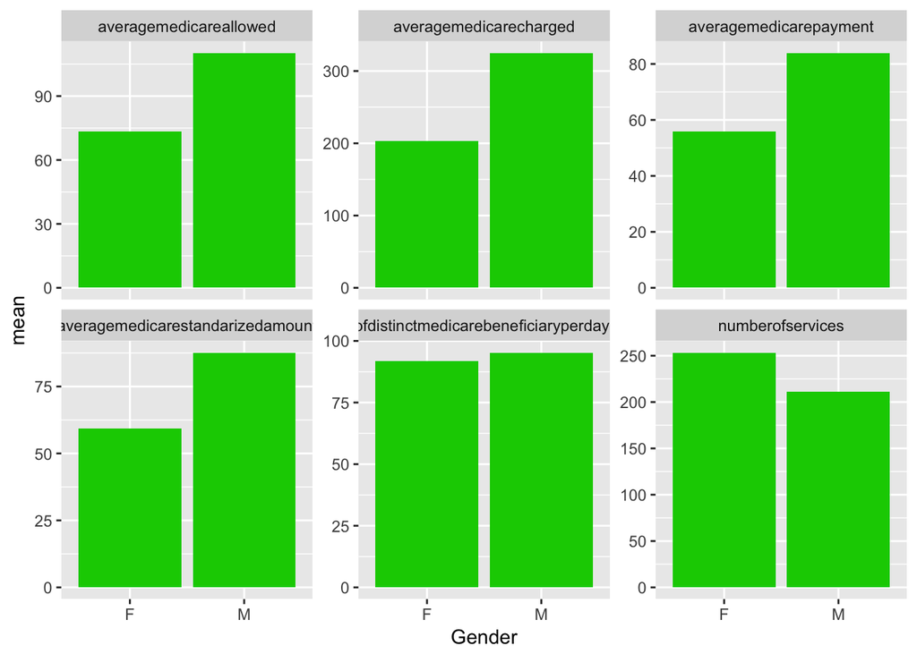

```r
ggplot(gendermeanfiltergather,aes(Gender,mean))+geom_bar(stat="identity", fill=67)+ facet_wrap(~Service, scale = "free_y")
```

### Analysis of Gender

In these set of graphs created to analyze the implications of gender we notice a trend similar to that of place of service. With place of service there was a higher cost but less services provided when it came to facilites and a lower cost but higher number of services with offices. Here with gender we see a similar pattern in that men are like that of the facilities in that they charge more but provide less services while women are like that of the offices in that they charge less but provide more.

## Medicare Variables as a Funciton of Type of Provider

## Average Medicare Standardized Amount as a function of Type of Provider

```r
typeofprovider=providerspokane%>%group_by(providerType)%>%summarize(StandardAmmount=mean(Average.Medicare.Standardized.Amount))
typeofprovider <- typeofprovider[order(-typeofprovider$StandardAmmount),]
typeofprovider <- typeofprovider[1:20,]
typeofprovider
```

```
## # A tibble: 20 x 2
##                                providerType StandardAmmount
##                                      <fctr>           <dbl>
##  1               Ambulatory Surgical Center        863.6339
##  2               Ambulance Service Supplier        678.2427
##  3                          Cardiac Surgery        477.2205
##  4  Independent Diagnostic Testing Facility        300.2730
##  5                         Thoracic Surgery        241.5437
##  6                             Neurosurgery        239.2705
##  7           Interventional Pain Management        222.0683
##  8 Colorectal Surgery (formerly proctology)        210.0627
##  9                       Radiation Oncology        200.0966
## 10                         Vascular Surgery        194.2793
## 11                          General Surgery        189.4266
## 12                       Orthopedic Surgery        185.5774
## 13                            Ophthalmology        168.7890
## 14                   Gynecological/Oncology        154.6019
## 15                              Dermatology        134.5578
## 16                Cardiac Electrophysiology        134.3094
## 17                          Sports Medicine        131.7033
## 18                        Surgical Oncology        126.7595
## 19                         Gastroenterology        114.8370
## 20       Plastic and Reconstructive Surgery        114.0253
```

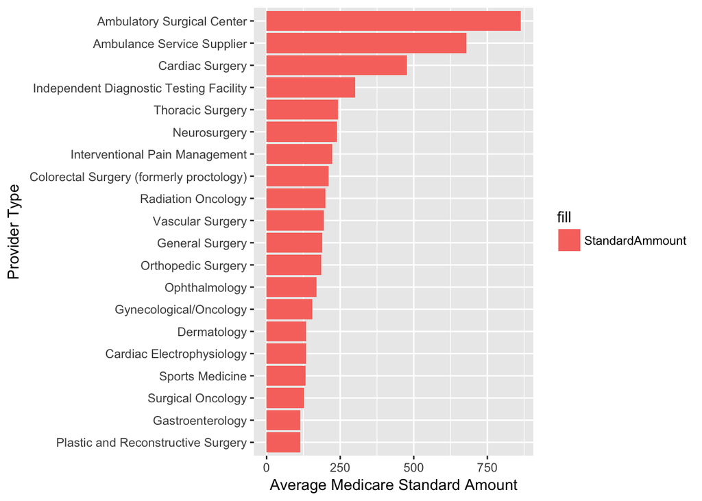

```r
ggplot(typeofprovider,aes(reorder(providerType,StandardAmmount),StandardAmmount,fill="StandardAmmount"))+geom_bar(stat="identity")+coord_flip()+ylab("Average Medicare Standard Amount")+xlab("Provider Type")
```

## Average Medicare Charge as a function of Type of Provider

```r
typeofprovider=providerspokane%>%group_by(providerType)%>%summarize(ChargeAmount=mean(Average.Submitted.Charge.Amount))
typeofprovider <- typeofprovider[order(-typeofprovider$ChargeAmount),]
typeofprovider <- typeofprovider[1:20,]
```

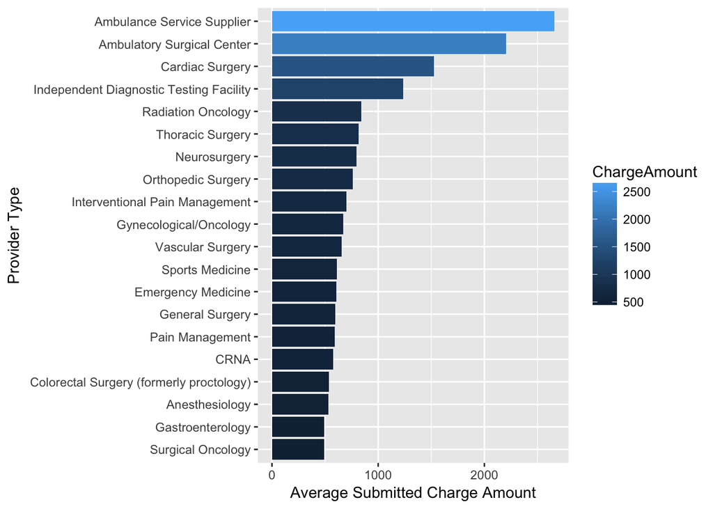

```r
ggplot(typeofprovider,aes(reorder(providerType,ChargeAmount),ChargeAmount,fill=ChargeAmount))+geom_bar(stat="identity")+coord_flip()+ylab("Average Submitted Charge Amount")+xlab("Provider Type")
```

## Average Medicare Payment Amount as a function of Type of Provider

```r
typeofprovider=providerspokane%>%group_by(providerType)%>%summarize(PaymentAmount=mean(Average.Medicare.Payment.Amount))
typeofprovider <- typeofprovider[order(-typeofprovider$PaymentAmount),]
typeofprovider <- typeofprovider[1:20,]
```

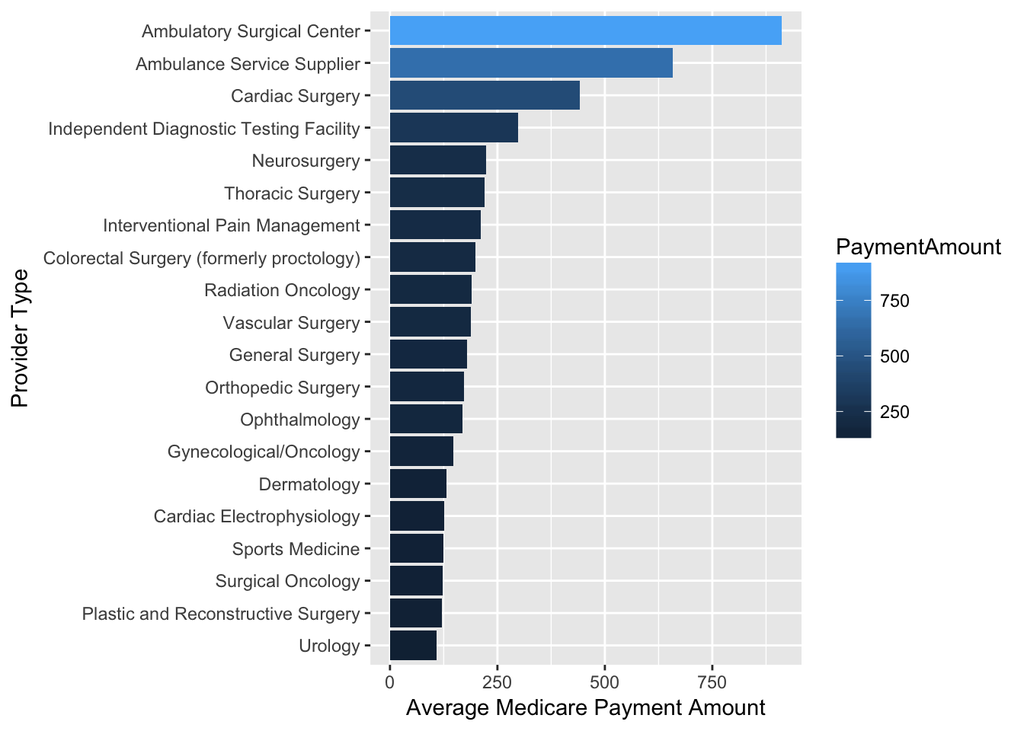

```r
ggplot(typeofprovider,aes(reorder(providerType,PaymentAmount),PaymentAmount,fill=PaymentAmount))+geom_bar(stat="identity")+coord_flip()+ylab("Average Medicare Payment Amount")+xlab("Provider Type")
```

## Average Medicare Allowed Amount as a function of Type of Provider

```r
typeofprovider=providerspokane%>%group_by(providerType)%>%summarize(AllowedAmount=mean(Average.Medicare.Allowed.Amount))
typeofprovider <- typeofprovider[order(-typeofprovider$AllowedAmount),]
typeofprovider <- typeofprovider[1:20,]
```

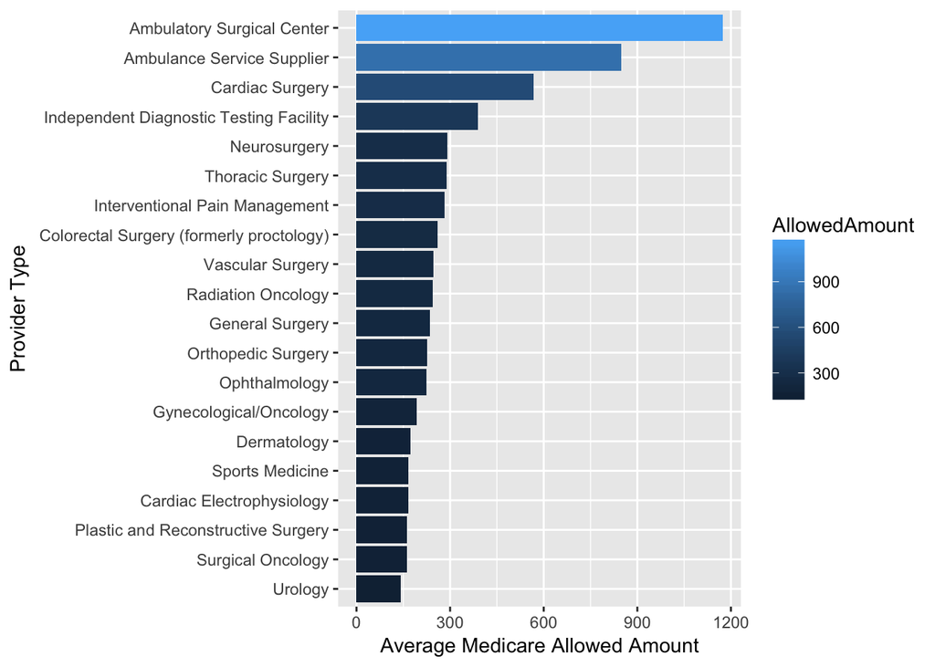

```r
ggplot(typeofprovider,aes(reorder(providerType,AllowedAmount),AllowedAmount,fill=AllowedAmount))+geom_bar(stat="identity")+coord_flip()+ylab("Average Medicare Allowed Amount")+xlab("Provider Type")
```

## Number of Services as a Function of Type of Provider

```r
typeofprovider=providerspokane%>%group_by(providerType)%>%summarize(NumberServices=mean(numServices))
typeofprovider <- typeofprovider[order(-typeofprovider$NumberServices),]
typeofprovider <- typeofprovider[1:20,]
```

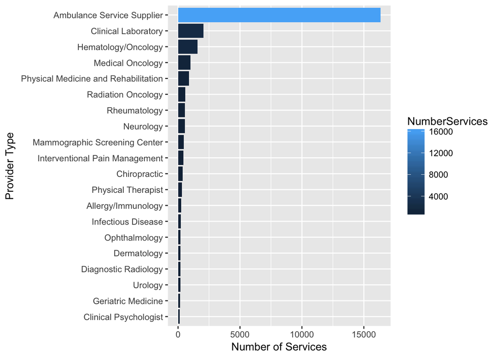

```r
ggplot(typeofprovider,aes(reorder(providerType,NumberServices),NumberServices,fill=NumberServices))+geom_bar(stat="identity")+coord_flip()+ylab("Number of Services")+xlab("Provider Type")
```